# Global Holidays

Author

Jo Hardin

Published

December 24, 2024

```r
library(tidyverse) # ggplot, lubridate, dplyr, stringr, readr...
library(praise)

library(reticulate)
use_python("/Users/jsh04747/miniforge3/bin/python3", required = TRUE)
```

Some notes to myself about how to install Python packages.

```
To install a package in Python:

In R:
reticulate::py_install("matplotlib")

In bash:
pip install matplotlib

or

python3 -m pip install matplotlib

In Python:
!pip install matplotlib
```

```python
import pandas as pd

import matplotlib.pyplot as plt
import seaborn as sns
```

## The Data

This week we’re exploring how global holidays impact seasonal human mobility. We found the data via the article [“Global holiday datasets for understanding seasonal human mobility and population dynamics” by Shengjie Lai (et al)](https://www.nature.com/articles/s41597-022-01120-z) (thank you to @lgibson7 for finding the dataset).

> Public and school holidays have important impacts on population mobility and dynamics across multiple spatial and temporal scales, subsequently affecting the transmission dynamics of infectious diseases and many socioeconomic activities. However, worldwide data on public and school holidays for understanding their changes across regions and years have not been assembled into a single, open-source and multitemporal dataset. To address this gap, an open access archive of data on public and school holidays in 2010–2019 across the globe at daily, weekly, and monthly timescales was constructed. Airline passenger volumes across 90 countries from 2010 to 2018 were also assembled to illustrate the usage of the holiday data for understanding the changing spatiotemporal patterns of population movements.

Sources:

Lai S., Sorichetta A. and WorldPop (2020). Global Public and School Holidays 2010-2019. Mapping seasonal denominator dynamics in low- and middle-income settings, and Exploring the seasonality of COVID-19, funded by The Bill and Melinda Gates Foundation.

Lai S., Sorichetta A. and WorldPop (2020). Monthly volume of airline passengers in 90 countries 2010-2018. Mapping seasonal denominator dynamics in low- and middle-income settings, and Exploring the seasonality of COVID-19, funded by The Bill and Melinda Gates Foundation.

## In R

```r
library(countrycode)
monthly_passengers <- readr::read_csv('https://raw.githubusercontent.com/rfordatascience/tidytuesday/main/data/2024/2024-12-24/monthly_passengers.csv')

iso_continent <- data.frame(
  ISO3 = unique(countrycode::codelist$iso3c),
  continent = countrycode(unique(countrycode::codelist$iso3c), "iso3c", "continent")
)
```

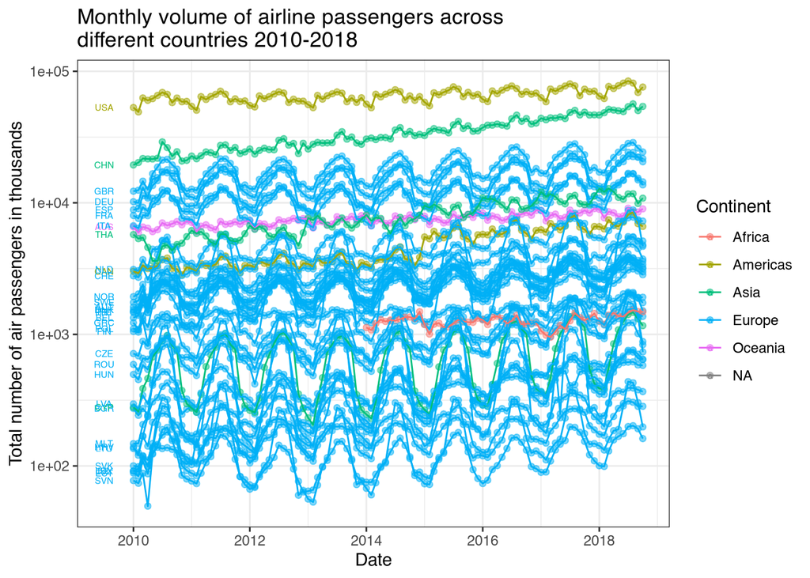

Line plot showing the number of airline passengers across countries and year-month.

```r
plot_data <- monthly_passengers |>
  left_join(iso_continent, by = c("ISO3" = "ISO3")) |>
  mutate(month_year = ymd(paste(Year, Month, "01", sep = "-")))

plot_data |>
  ggplot(aes(x = month_year, y = Total, group = ISO3, color = continent)) +
    geom_point(alpha = 0.5) +
  geom_line() +
  geom_text(data = filter(plot_data, Year == 2010, Month == 1),
            mapping = aes(label = ISO3, y = Total),
            x = ymd(paste("2009", "07","01", sep = "-")),
            size = 2) +
  scale_y_log10() +
  xlim(c(ymd("2009-07-01"), ymd("2018-10-01"))) +
  labs(y = "Total number of air passengers in thousands",
       x = "Date",
       color = "Continent",
       title = "Monthly volume of airline passengers across \ndifferent countries 2010-2018") +
  theme_bw()
```

## In Python

```python
monthly_passengers = pd.read_csv('https://raw.githubusercontent.com/rfordatascience/tidytuesday/main/data/2024/2024-12-24/monthly_passengers.csv')

print(monthly_passengers)
```

```
     ISO3  Year  Month  Total  Domestic  International  Total_OS
0     ALB  2010      1    NaN       NaN            NaN   117.350
1     ALB  2010      2    NaN       NaN            NaN    86.535
2     ALB  2010      3    NaN       NaN            NaN   103.795
3     ALB  2010      4    NaN       NaN            NaN   102.038
4     ALB  2010      5    NaN       NaN            NaN   109.037
...   ...   ...    ...    ...       ...            ...       ...
7237  ZAF  2017      8    NaN       NaN            NaN  3425.617
7238  ZAF  2017      9    NaN       NaN            NaN  3454.075
7239  ZAF  2017     10    NaN       NaN            NaN  3678.780
7240  ZAF  2017     11    NaN       NaN            NaN  3482.341
7241  ZAF  2017     12    NaN       NaN            NaN  3812.322

[7242 rows x 7 columns]
```

```
pip install pycountry pycountry-convert
```

```python
import pycountry_convert as pc
import numpy as np

def get_continent(iso3):
    try:
        # Convert ISO3 to ISO2
        iso2 = pc.country_alpha3_to_country_alpha2(iso3)
        # Get continent code
        continent_code = pc.country_alpha2_to_continent_code(iso2)
        # Map continent codes to names
        continents = {
            "AF": "Africa",
            "AS": "Asia",
            "EU": "Europe",
            "NA": "North America",
            "SA": "South America",
            "OC": "Oceania",
            "AN": "Antarctica"
        }
        return continents[continent_code]
    except Exception:
        return "Unknown"

# Apply the function to the ISO3 column
monthly_passengers['Continent'] = monthly_passengers['ISO3'].apply(get_continent)

monthly_passengers['month_year'] = pd.to_datetime(monthly_passengers['Year'].astype(str) + '-' + monthly_passengers['Month'].astype(str), format='%Y-%m')



print(monthly_passengers)
```

```
     ISO3  Year  Month  Total  ...  International  Total_OS  Continent month_year
0     ALB  2010      1    NaN  ...            NaN   117.350     Europe 2010-01-01
1     ALB  2010      2    NaN  ...            NaN    86.535     Europe 2010-02-01
2     ALB  2010      3    NaN  ...            NaN   103.795     Europe 2010-03-01
3     ALB  2010      4    NaN  ...            NaN   102.038     Europe 2010-04-01
4     ALB  2010      5    NaN  ...            NaN   109.037     Europe 2010-05-01
...   ...   ...    ...    ...  ...            ...       ...        ...        ...
7237  ZAF  2017      8    NaN  ...            NaN  3425.617     Africa 2017-08-01
7238  ZAF  2017      9    NaN  ...            NaN  3454.075     Africa 2017-09-01
7239  ZAF  2017     10    NaN  ...            NaN  3678.780     Africa 2017-10-01
7240  ZAF  2017     11    NaN  ...            NaN  3482.341     Africa 2017-11-01
7241  ZAF  2017     12    NaN  ...            NaN  3812.322     Africa 2017-12-01

[7242 rows x 9 columns]
```

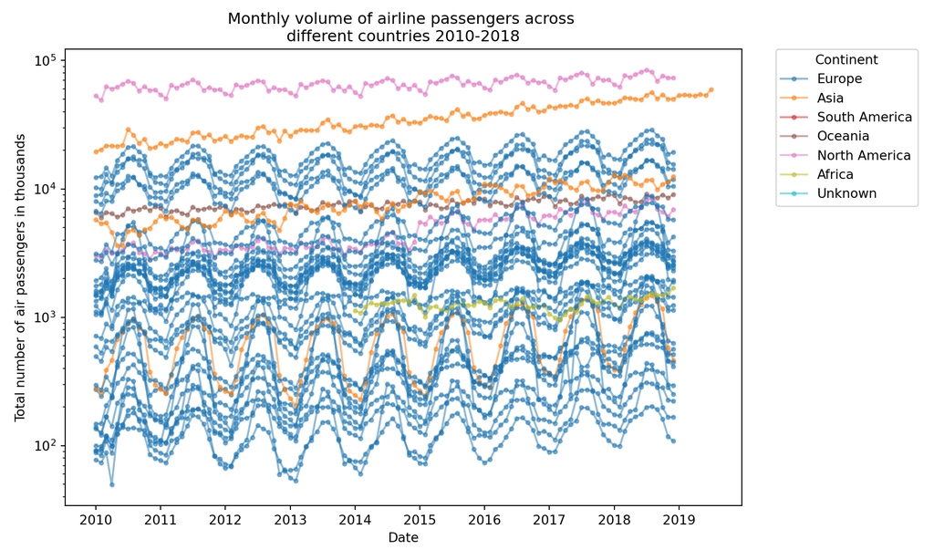

Line plot showing the number of airline passengers across countries and year-month.

```python
categories = monthly_passengers['Continent'].unique()
colors = plt.cm.tab10(np.linspace(0, 1, len(categories)))

continent_to_color = {continent: i for i, continent in enumerate(categories)}
handled_continents = set()

plt.figure(figsize=(10, 6))


for iso3 in monthly_passengers['ISO3'].unique():
    country_data = monthly_passengers[monthly_passengers['ISO3'] == iso3]
    continent = country_data['Continent'].iloc[0]
    color = colors[continent_to_color[continent]]

    label = continent if continent not in handled_continents else None
    plt.plot(
        country_data['month_year'],
        country_data['Total'],
        label=label,
        color=color,
        marker='o',
        markersize=3,
        alpha=0.5)
    handled_continents.add(continent)


plt.xlabel('Date')
plt.ylabel('Total number of air passengers in thousands')
plt.title('Monthly volume of airline passengers across \ndifferent countries 2010-2018')
plt.yscale('log')
plt.legend(title="Continent", loc='upper left', bbox_to_anchor=(1.05, 1), borderaxespad=0)
plt.tight_layout()

plt.savefig("holidaytravel.png", dpi=300, bbox_inches='tight')

plt.show()
```

```r
praise()
```

```
[1] "You are bee's knees!"
```